[figure not shown]

# STANDAARDISEREN

In deze notebook leer je bivariate gegevens weergeven in een puntenwolk. Je leert dat je de mate van correlatie niet altijd op het zicht kunt inschatten en waarom het standaardiseren van de gegevens in dat opzicht belangrijk is.

Voor deze notebook werden we geïnspireerd door het lesmateriaal 'Statistiek voor het secundair onderwijs' dat je kan vinden op de website https://www.uhasselt.be/lesmateriaal-statistiek van de Universiteit Hasselt [1][2]. De voorbeelden uit [2] werd in deze notebook overgenomen met toestemming van professor Callaert.

### De nodige modules importeren

```python
import numpy as np
import matplotlib.pyplot as plt
import pandas as pd
```

In wat volgt zul je drie puntenwolken met elkaar vergelijken en inschatten welke data de beste lineaire correlatie vertonen.  
Lotte, Robbe en Kato krijgen elk een aantal bloemblaadjes waarvan ze de lengte en de breedte moeten opmeten in millimeter.  
Ze lijsten hun meetresultaten op in respectievelijk tabel1, tabel2 en tabel3.  
Vervolgens representeren ze de bivariate gegevens met een puntenwolk.

Rechtstreeks op een figuur schatten hoe sterk de lineaire samenhang is, is niet zo eenvoudig.

## 1. Inlezen van de data

Lees met de module pandas de datasets in.

```python
lotte = pd.read_csv("data/datastandaard1.dat", header=None)  # in te lezen tabel heeft geen hoofding
robbe = pd.read_csv("data/datastandaard2.dat", header=None)  # in te lezen tabel heeft geen hoofding
katoo = pd.read_csv("data/datastandaard3.dat", header=None)  # in te lezen tabel heeft geen hoofding
```

## 2. Tonen van de ingelezen data

### Opdracht 2.1

Kijk de gegevens van de drie tabellen in.

```python
lotte
```

|  | 0 | 1 |
| --- | --- | --- |
| 0 | 16.25 | 4.6 |
| 1 | 16.75 | 3.4 |
| 2 | 17.00 | 27.4 |
| 3 | 17.25 | 14.2 |
| 4 | 17.75 | 28.6 |
| 5 | 18.25 | 3.4 |
| 6 | 18.50 | 14.2 |
| 7 | 18.75 | 16.6 |
| 8 | 19.00 | 13.0 |
| 9 | 19.25 | 26.2 |
| 10 | 19.75 | 19.0 |
| 11 | 20.00 | 23.8 |
| 12 | 20.25 | 34.6 |
| 13 | 20.50 | 14.2 |
| 14 | 20.75 | 25.0 |
| 15 | 21.25 | 17.8 |
| 16 | 21.75 | 11.8 |
| 17 | 22.00 | 13.0 |
| 18 | 22.25 | 41.8 |
| 19 | 23.00 | 39.4 |

```python
robbe
```

|  | 0 | 1 |
| --- | --- | --- |
| 0 | 9 | 21.000 |
| 1 | 11 | 20.875 |
| 2 | 12 | 23.375 |
| 3 | 13 | 22.000 |
| 4 | 15 | 23.500 |
| 5 | 17 | 20.875 |
| 6 | 18 | 22.000 |
| 7 | 19 | 22.250 |
| 8 | 20 | 21.875 |
| 9 | 21 | 23.250 |
| 10 | 23 | 22.500 |
| 11 | 24 | 23.000 |
| 12 | 25 | 24.125 |
| 13 | 26 | 22.000 |
| 14 | 27 | 23.125 |
| 15 | 29 | 22.375 |
| 16 | 31 | 21.750 |
| 17 | 32 | 21.875 |
| 18 | 33 | 24.875 |
| 19 | 36 | 24.625 |

```python
katoo
```

|  | 0 | 1 |
| --- | --- | --- |
| 0 | 20.125 | 8 |
| 1 | 20.175 | 7 |
| 2 | 20.200 | 27 |
| 3 | 20.225 | 16 |
| 4 | 20.275 | 28 |
| 5 | 20.325 | 7 |
| 6 | 20.350 | 16 |
| 7 | 20.375 | 18 |
| 8 | 20.400 | 15 |
| 9 | 20.425 | 26 |
| 10 | 20.475 | 20 |
| 11 | 20.500 | 24 |
| 12 | 20.525 | 33 |
| 13 | 20.550 | 16 |
| 14 | 20.575 | 25 |
| 15 | 20.625 | 19 |
| 16 | 20.675 | 14 |
| 17 | 20.700 | 15 |
| 18 | 20.725 | 39 |
| 19 | 20.800 | 37 |

### Opdracht 2.2

Geef de juiste instructie in om info te verkrijgen over de tweede tabel.

- Wat zijn de namen van de kolommen?
- Hoeveel bloemblaadjes heeft Robbe opgemeten?

Antwoord:

## 3. De data weergeven in puntenwolk

Omdat de tabellen geen header hebben, kan je geen header als sleutel gebruiken. Je kan dan in de plaats het kolomnummer gebruiken.

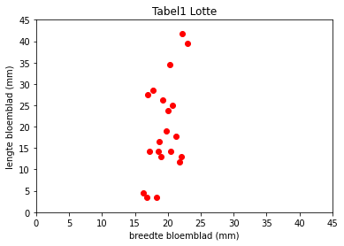

```python
# tabel1
x1 = lotte[0]
y1 = lotte[1]
x1 = np.array(x1)
y1 = np.array(y1)

plt.figure()

plt.title("Tabel1 Lotte")
plt.xlabel("breedte bloemblad (mm)")
plt.ylabel("lengte bloemblad (mm)")
plt.xlim(0, 45)
plt.ylim(0, 45)

plt.scatter(x1, y1, color="red", marker="o")

plt.show()
```

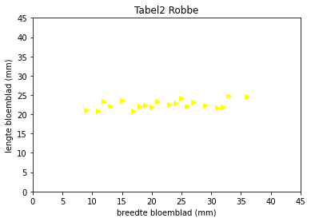

```python
# tabel2
x2 = robbe[0]
y2 = robbe[1]
x2 = np.array(x2)
y2 = np.array(y2)

plt.figure()

plt.title("Tabel2 Robbe")
plt.xlabel("breedte bloemblad (mm)")
plt.ylabel("lengte bloemblad (mm)")
plt.xlim(0, 45)
plt.ylim(0, 45)

plt.scatter(x2, y2, color="yellow", marker=">")

plt.show()
```

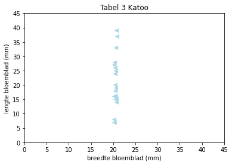

```python
# tabel3
x3 = katoo[0]
y3 = katoo[1]
x3 = np.array(x3)
y3 = np.array(y3)

plt.figure()


plt.title("Tabel 3 Katoo")
plt.xlabel("breedte bloemblad (mm)")
plt.ylabel("lengte bloemblad (mm)")
plt.xlim(0, 45)
plt.ylim(0, 45)

plt.scatter(x3, y3, color="lightblue", marker="<")

plt.show()
```

Bij welke tabel is er de beste lineaire samenhang?

Op het eerste gezicht bij tabel Katoo

## 4. Correlatie

Het is niet vanzelfsprekend om de lineaire correlatie tussen gegevens in te schatten louter afgaand op de puntenwolk. Een betere houvast is de correlatiecoëfficiënt.

In hoeverre er lineaire samenhang is tussen de x- en y- coördinaat van de gegeven punten, kan bekeken worden a.d.h.v. de *correlatiecoëfficiënt R*.

De correlatiecoëfficiënt, een reëel getal R, ligt steeds tussen -1 en 1. Hoe dichter R bij 0 ligt, hoe slechter de lineaire samenhang.  
Bij een positieve R spreekt men van een positieve lineaire samenhang, bij een negatieve R van een negatieve lineaire samenhang.

Vergelijk de correlatiecoëfficiënten van de drie tabellen. Vul eerst de instructies in de code-cel aan.

```python
# correlatiecoëfficiënt van tabel 1
print("Correlatiecoëfficiënt R1 van de eerste tabel =", np.corrcoef(x1, y1)[0,1])
```

```
Correlatiecoëfficiënt R1 van de eerste tabel = 0.5000189861332996
```

```python
# correlatiecoëfficiënt van tabel 2 en tabel 3
print("Correlatiecoëfficiënt R1 van de eerste tabel =", np.corrcoef(x1, y1)[0,1])
print("Correlatiecoëfficiënt R2 van de eerste tabel =", np.corrcoef(x2, y2)[0,1])
print("Correlatiecoëfficiënt R3 van de eerste tabel =", np.corrcoef(x3, y3)[0,1])
```

```
Correlatiecoëfficiënt R1 van de eerste tabel = 0.5000189861332996
Correlatiecoëfficiënt R2 van de eerste tabel = 0.5000189861332996
Correlatiecoëfficiënt R3 van de eerste tabel = 0.5000189861332992
```

Wat besluit je over de lineaire correlatie voor de drie tabellen?

Antwoord:

## 5. Standaardiseren

De gegevens kunnen maar vergeleken worden als ze gestandaardiseerd zijn. Je berekent daarvoor de *Z-score* van de gegevens: je trekt het gemiddelde af en je deelt vervolgens door de standaardafwijking.

```python
x1 = (x1-np.mean(x1))/np.std(x1)
y1 = (y1-np.mean(y1))/np.std(y1)
x2 = (x2-np.mean(x2))/np.std(x2)
y2 = (y2-np.mean(y2))/np.std(y2)
x3 = (x3-np.mean(x3))/np.std(x3)
y3 = (y3-np.mean(y3))/np.std(y3)
```

Je kunt nu de puntenwolken tekenen die corresponderen met deze aangepaste gegevens.

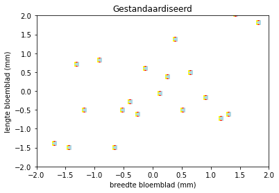

```python
# gestandaardiseerde puntenwolk

plt.figure()

plt.scatter(x1, y1, color="red", marker="o")
plt.scatter(x2, y2, color="yellow", marker=">")
plt.scatter(x3, y3, color="lightblue", marker="<")

plt.title("Gestandaardiseerd")
plt.xlabel("breedte bloemblad (mm)")
plt.ylabel("lengte bloemblad (mm)")
plt.xlim(-2, 2)
plt.ylim(-2, 2)

plt.show()
```

De lineaire correlatie is nagenoeg dezelfde voor alle drie de tabellen. Na standaardisatie vallen de punten quasi samen.

Meer uitleg over deze begrippen kan je vinden in de cursus 'Correlatie: exploratieve methoden: werktekst voor de leerling'. [1]

De correlatie van meerdere datasets met elkaar vergelijken, gaat het best als je de gegevens eerst hebt gestandaardiseerd. Het standaardiseren heeft trouwens geen effect op de waarde van de correlatiecoëfficiënt.  
De correlatie tussen **bivariate gegevens** bv. kan men visueel inschatten door de overeenkomstige **puntenwolk** te bekijken. De vorm hiervan is echter maar betrouwbaar als de gegevens gestandaardiseerd zijn.  
**Standaardiseren** van variabelen houdt in dat men de variabelen op zo'n manier herschaalt dat men variabelen van bv. een verschillende grootteorde of in een verschillende eenheid met elkaar kan vergelijken of in verband brengen.

## Referentielijst

[1] Callaert, H., Bekaert, H., Goethals, C., Provoost, L., & Vancaudenberg, M. (2012). Correlatie: exploratieve methoden: werktekst voor de leerling.  
*Statistiek voor het secundair onderwijs.* Universiteit Hasselt. Geraadpleegd op 15 april 2019 via  
https://www.uhasselt.be/documents/uhasselt@school/lesmateriaal/statistiek/Lesmateriaal/LEERLING%20Correlatie_02.pdf.  
[2] Callaert, H.,& Bogaerts, S. (2004). Statistische Intelligentie: de samenhang ontdekken: exploratie van bivariaat cijfermateriaal. Universiteit Hasselt.  
Geraadpleegd op 15 april 2019 via https://docplayer.nl/32671814-Statistische-intelligentie.html.

Notebook Python en wiskunde, zie [AI Op School](http://www.aiopschool.be), van F. wyffels & N. Gesquière is in licentie gegeven volgens een [Creative Commons Naamsvermelding-NietCommercieel-GelijkDelen 4.0 Internationaal-licentie](http://creativecommons.org/licenses/by-nc-sa/4.0/).